# L3 Raster data

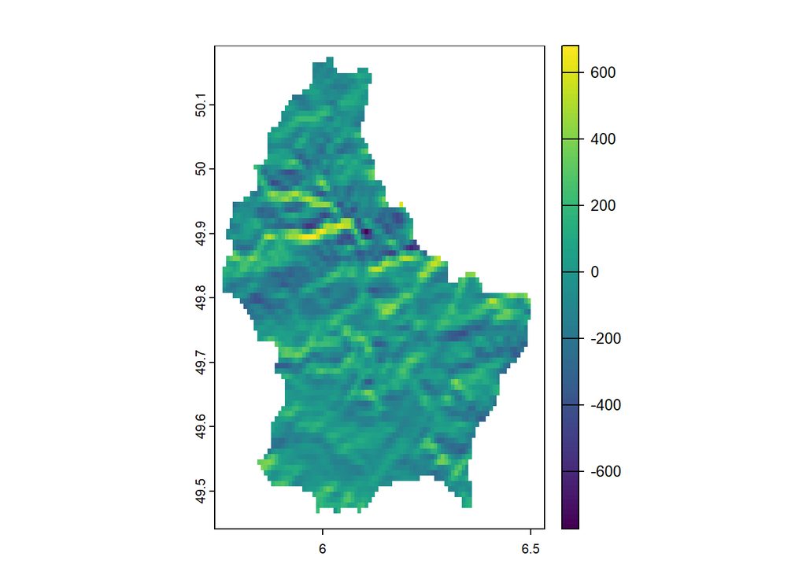

```r
# Apply a convolution filter (e.g., Sobel filter for edge detection)
sobel_filter <- matrix(c(-1, 0, 1, -2, 0, 2, -1, 0, 1), nrow = 3, ncol = 3)
neighborhood_raster <- focal(fras, w = sobel_filter, fun = sum)

# View the result
plot(neighborhood_raster)
```

```r
gaussian_kernel <- matrix(c(1, 2, 1, 2, 4, 2, 1, 2, 1) / 16, nrow = 3, ncol = 3)

# Apply the kernel as a convolution filter (a neighborhood function)
filtered_raster <- focal(fras, w = gaussian_kernel, fun = sum)
```

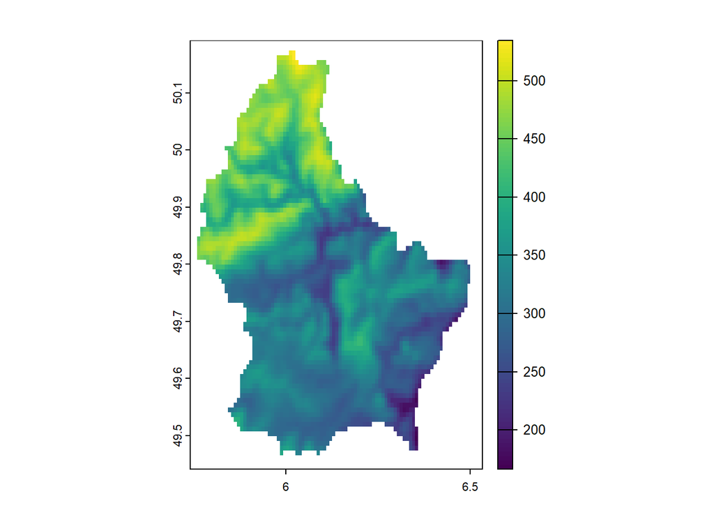

```r
# View the result
plot(filtered_raster)
```

(Advanced) Visualise using ggplot2 and tidyterra:

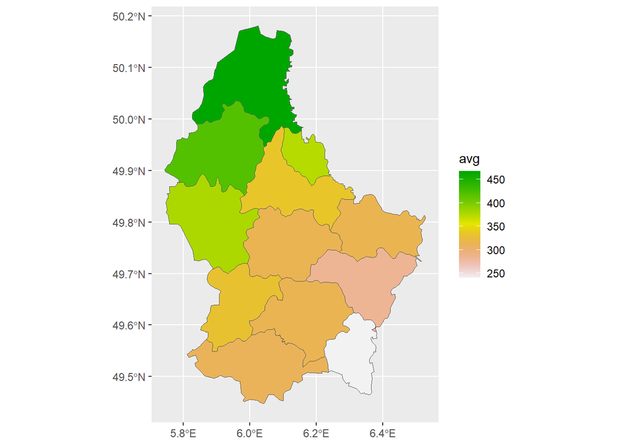

```r
#install.packages("ggplot2")
#install.packages("tidyterra")
library(ggplot2)
library(tidyterra)
fvec$avg =pavg
ggplot(data= fvec) +geom_spatvector(aes(fill = avg)) +scale_fill_terrain_c()
```

More about making maps in R [https://www.paulamoraga.com/book-spatial/making-maps-with-r.html]

# Exercise

1. read the document of **worldclim** climate data download function in geodata [https://rdrr.io/cran/geodata/man/worldclim.html] and then download monthly averaged total precipitation of Germany, at 1000 m resolution. How large is the dataset?
2. plot the first layer (the averaged precipitation of January)
3. create a map for annual average total precipitation (average over months and), plot the map.
4. Download the administrative boundary of Germany with the first level of subdivition. (HINT: You can use **gadm** from **geodata** package: Ger = gadm(“Germany”, level =1, path = tempdir()))
5. Only show the map to the extent of Germany (that is, only show the precipitation in Germany, outside Germany should be masked out).
6. Show the map that include the annual precipitation, first level administrative boundary of Germany (level at Bundesland/state), and the centroid of each polygon.
7. Extract the annual averaged precipitation value at the centroid of each Bundesland (state).
8. Calculate the mean annual averaged precipitation over each bundesland.
9. Use an Raster image (you can use the ones used in the lectures or one of your own) 9.1. Perform a smoothing, describe your methods for smoothing and why you chose the method. 9.2. Implement sobel kernel convolusion in left-right and up-down directions.

```r
library(geodata)
library(terra)
library(ggplot2)
library(tidyterra)
```

```r
prec <- geodata::worldclim_country(country = "Germany", var = "prec",
                                res = 1000, path = tempdir())
prec
```

```
## class       : SpatRaster
## dimensions  : 1020, 1200, 12  (nrow, ncol, nlyr)
## resolution  : 0.008333333, 0.008333333  (x, y)
## extent      : 5.5, 15.5, 47, 55.5  (xmin, xmax, ymin, ymax)
## coord. ref. : lon/lat WGS 84 (EPSG:4326)
## source      : DEU_wc2.1_30s_prec.tif
## names       : DEU_w~rec_1, DEU_w~rec_2, DEU_w~rec_3, DEU_w~rec_4, DEU_w~rec_5, DEU_w~rec_6, ...
## min values  :          19,          18,          20,          24,          30,          35, ...
## max values  :         200,         184,         183,         191,         178,         230, ...
```

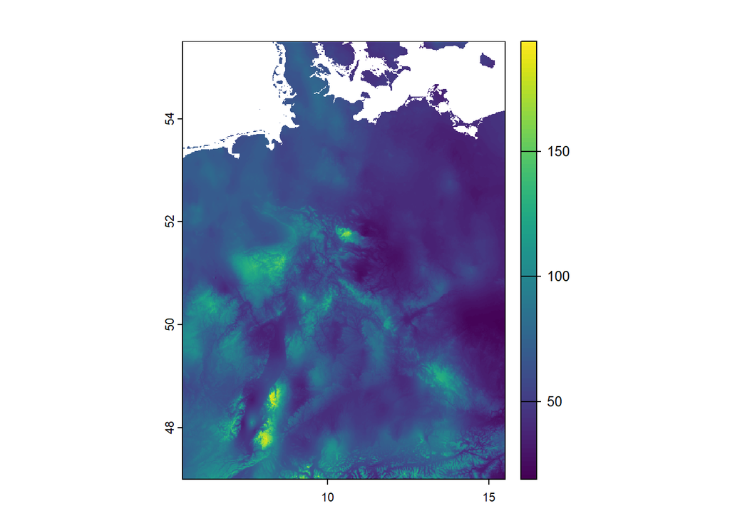

```r
plot(prec$DEU_wc2.1_30s_prec_1)
```

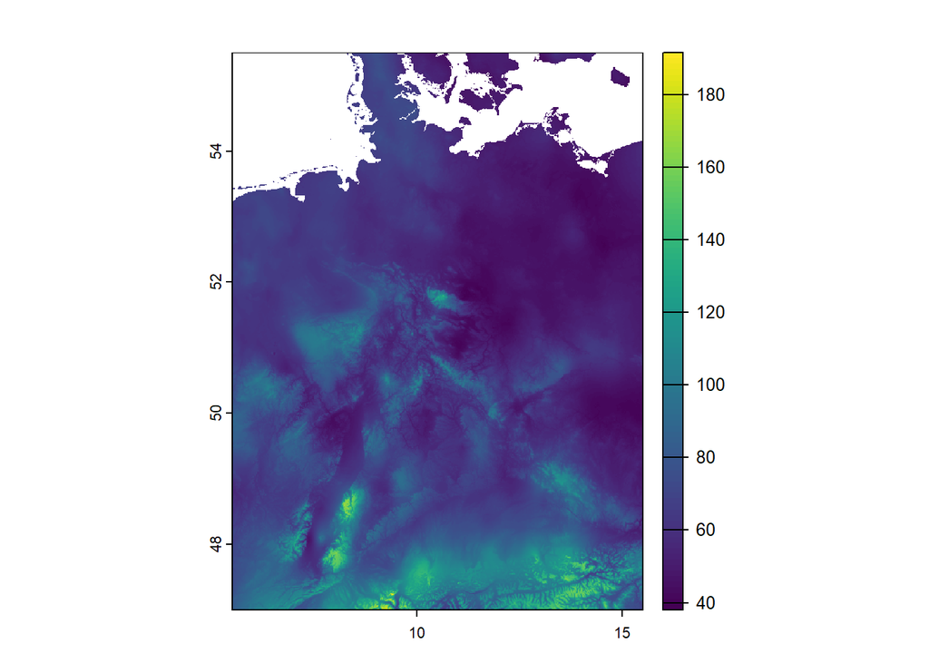

```r
mprec = mean(prec)
plot(mprec)
```

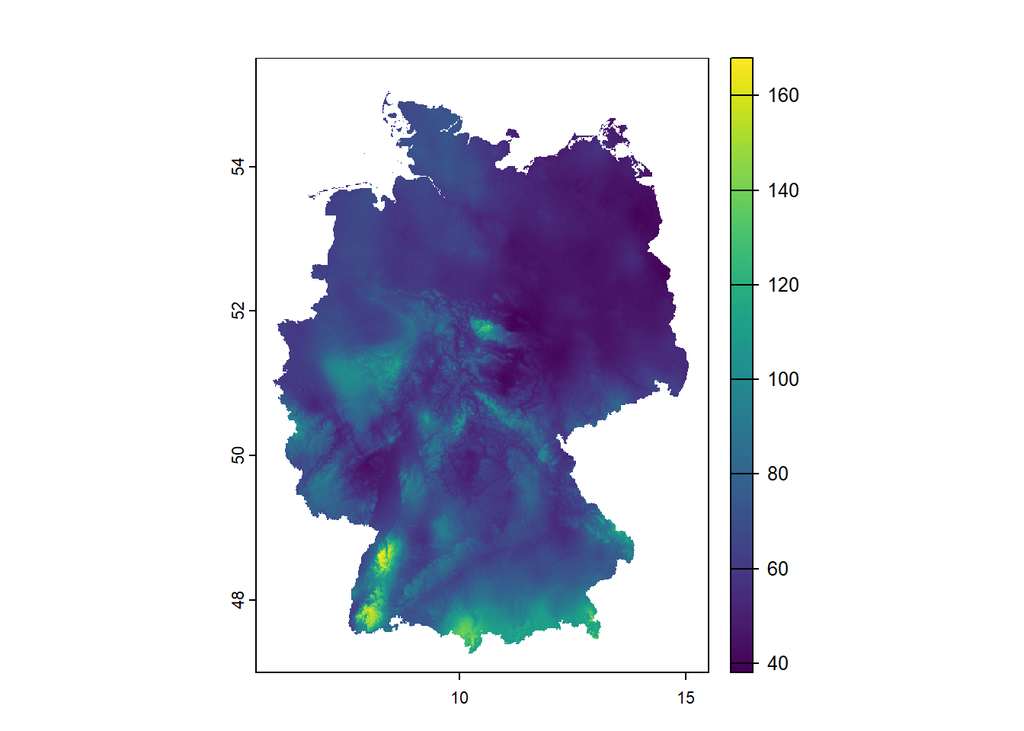

```r
Germany = world[world$name_long == "Germany", 1 ]
#cmprec=crop(mprec,Germany)

cprec <- terra::mask(mprec, vect(Germany))

Ger = gadm("Germany", level =1, path = tempdir())
cprec2 <- terra::mask(mprec, Ger)
plot(cprec2)
```

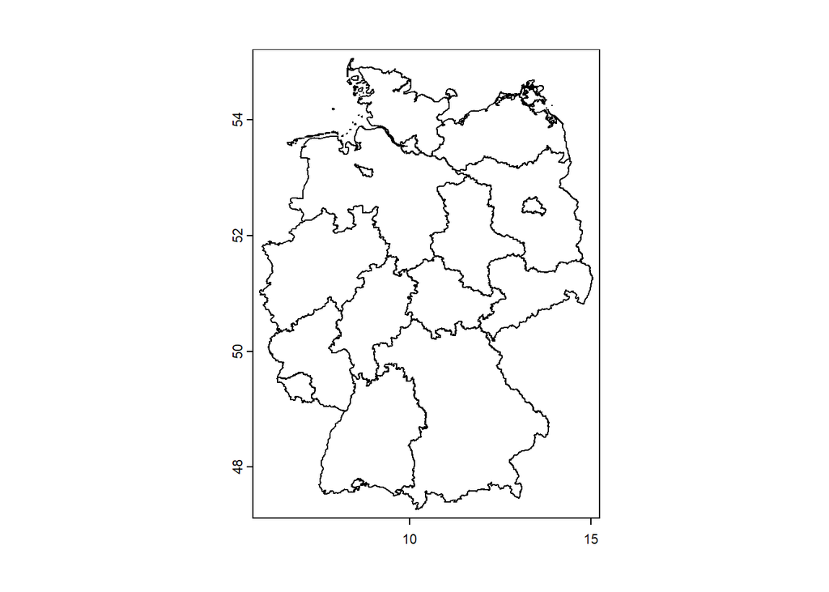

```r
plot(Ger)
```

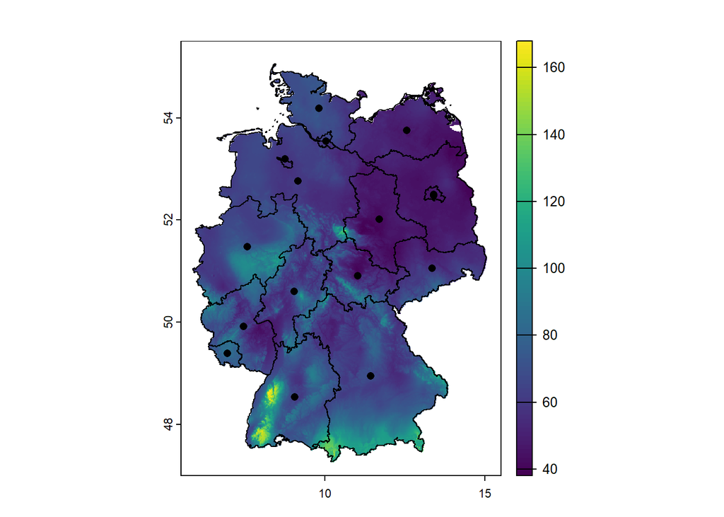

```r
cen=centroids(Ger)
plot(cprec2)
plot(Ger, add=T)
plot(cen, add=T)
```

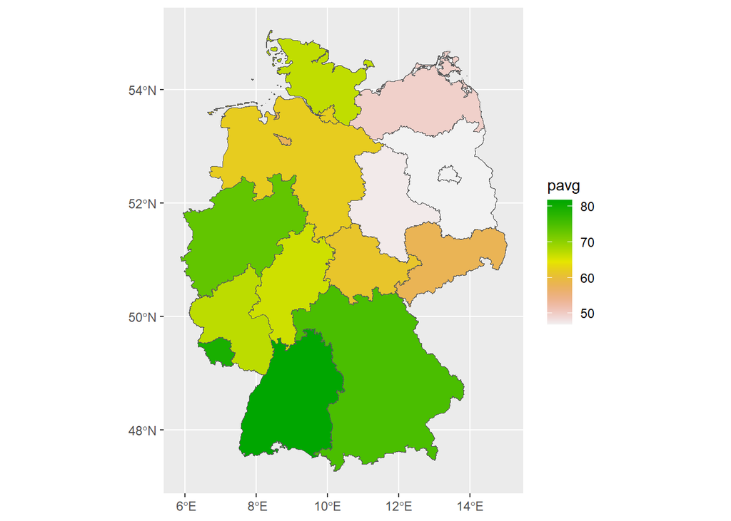

```r
Ger$pavg <- extract(cprec2, Ger, mean, na.rm = TRUE)$mean
ggplot(data= Ger) +geom_spatvector(aes(fill = pavg)) +scale_fill_terrain_c()
```